# PEC 2 Anàlisis de Dades Òmiques

Sheddad Kaid-Salah Ferrón

2023-12-20

# 1 Introducció i Objectius

# 2 Mètodes

## 2.1 Preparació del sistema: directoris i paquets

Oraganitzem el projecte fent servir directoris per ordenar les dades i els resultats.

```r
workingDir <- getwd()
dataDir <- file.path(workingDir, "data")
resultsDir <- file.path(workingDir, "results")
```

```r
# De moment no l'executem perquè no ens ho faci cada vegada
if (!require(BiocManager)) install.packages("BiocManager")

installifnot <- function(pkg) {
    if (!require(pkg, character.only = T)) {
        BiocManager::install(pkg)
    }
}
# BiocManager::install() # Actualitza paquets instal·lats
installifnot("rae230a.db")
installifnot("mogene10sttranscriptcluster.db")
installifnot("oligo")
installifnot("limma")
installifnot("Biobase")
installifnot("arrayQualityMetrics")
installifnot("genefilter")
installifnot("annotate")
installifnot("xtable")
installifnot("gplots")
installifnot("GOstats")
installifnot("GEOquery")
```

## 2.2 Lectura de les dades

### 2.2.1 Dades crues (Raw Data)

```r
require(Biobase)
# Llegim l'arxiu targets.csv en un dataframe
targetsDF <- read.csv(file = file.path(dataDir, "targets.csv"), header = TRUE, sep = ",")
# Visualitzem l'arxiu targets
targetsDF
```

```
      fileName     groups ShortName Colors
1 GSM45184.CEL    Control   84_Norm   blue
2 GSM45186.CEL    Control   86_Norm   blue
3 GSM45187.CEL    Control   87_Norm   blue
4 GSM45189.CEL    Control   89_Norm   blue
5 GSM45193.CEL    Control   93_Norm   blue
6 GSM45188.CEL Hypotesion   88_Hypo    red
7 GSM45190.CEL Hypotesion   90_Hypo    red
8 GSM45191.CEL Hypotesion   91_Hypo    red
9 GSM45192.CEL Hypotesion   92_Hypo    red
```

```r
# Definim variables pels gràfics
sampleNames <- as.character(targetsDF$ShortName)
sampleColor <- as.character(targetsDF$Colors)
# Creem un objecte AnnotatedDataFrame
targets <- AnnotatedDataFrame(targetsDF)
```

Extraurem les dades del arxius .CEL que ens hem descarregat i hem guardat al fitxer *dades*.

Llegim els arxius .CEL fent servir la informació continguda en el data frame *targets*.  
Gurdarem les dades en l’objecte *rawData* que és del tipus *ExpressionFeatureSet*, un tipus especial *d’ExpressionSet*.

```r
# Fitxers .CEL amb la info que hem tret de l'arxiu 'target.csv'
CELfiles <- targetsDF$fileName
rawData <- read.celfiles(file.path(dataDir, CELfiles), phenoData = targets)
```

```
Reading in : /home/sheddad/Escriptori/PEC_2_ADO/MasterBioInf-ADO-PEC2_GeneAnalisys/data/GSM45184.CEL
Reading in : /home/sheddad/Escriptori/PEC_2_ADO/MasterBioInf-ADO-PEC2_GeneAnalisys/data/GSM45186.CEL
Reading in : /home/sheddad/Escriptori/PEC_2_ADO/MasterBioInf-ADO-PEC2_GeneAnalisys/data/GSM45187.CEL
Reading in : /home/sheddad/Escriptori/PEC_2_ADO/MasterBioInf-ADO-PEC2_GeneAnalisys/data/GSM45189.CEL
Reading in : /home/sheddad/Escriptori/PEC_2_ADO/MasterBioInf-ADO-PEC2_GeneAnalisys/data/GSM45193.CEL
Reading in : /home/sheddad/Escriptori/PEC_2_ADO/MasterBioInf-ADO-PEC2_GeneAnalisys/data/GSM45188.CEL
Reading in : /home/sheddad/Escriptori/PEC_2_ADO/MasterBioInf-ADO-PEC2_GeneAnalisys/data/GSM45190.CEL
Reading in : /home/sheddad/Escriptori/PEC_2_ADO/MasterBioInf-ADO-PEC2_GeneAnalisys/data/GSM45191.CEL
Reading in : /home/sheddad/Escriptori/PEC_2_ADO/MasterBioInf-ADO-PEC2_GeneAnalisys/data/GSM45192.CEL
```

```r
rawData
```

```
ExpressionFeatureSet (storageMode: lockedEnvironment)
assayData: 362404 features, 9 samples
  element names: exprs
protocolData
  rowNames: 1 2 ... 9 (9 total)
  varLabels: exprs dates
  varMetadata: labelDescription channel
phenoData
  rowNames: 1 2 ... 9 (9 total)
  varLabels: fileName groups ShortName Colors
  varMetadata: labelDescription channel
featureData: none
experimentData: use 'experimentData(object)'
Annotation: pd.rae230a
```

### 2.2.2 Descàrrega de dades amb `GEOquery`

Tot i que he decidit fer tot l’estudi amb les dades crues (raw data) hi ha l’opció d’extreure les dades directament de la base de dades *Gene Expression Omnibus* [GEO](https://www.ncbi.nlm.nih.gov/geo/) fent servir la llibreria *GEOquery* de *Biobase (Bioconductor)*.  
Una de les ventatges és que aquestes dades ja estan normalitzades.

Aquesta és la manera d’extreure les dades amb l’identificador GDS.

```r
# Carreguem la llibreria GEOquery
require(GEOquery)

# Amb l'identificador GSE de l'estudi descarreguem les dades de GEO gse <-
# getGEO('GSE2401', GSEMatrix=TRUE, AnnotGPL=TRUE) gseEset <- gse[[1]]
# head(exprs(gseEset))

# Amb l'identificador GDS de l'estudi descarreguem les dades de GEO
gds <- getGEO("GDS1251", GSEMatrix = TRUE, AnnotGPL = TRUE)
# Tipus d'objecte
class(gds)
```

```
[1] "GDS"
attr(,"package")
[1] "GEOquery"
```

```r
head(Meta(gds))
```

```
$channel_count
[1] "1"

$dataset_id
[1] "GDS1251" "GDS1251"

$description
[1] "Expression profiling of kidneys of 12 week old normotensive Wistar-Kyoto males subjected to acute hypotension by withdrawing 3 ml of blood. Results provide insight into vasoregulatory mechanisms and the genetics and physiology of blood pressure regulation."
[2] "control"
[3] "acute hypotension"

$email
[1] "geo@ncbi.nlm.nih.gov"

$feature_count
[1] "15923"

$institute
[1] "NCBI NLM NIH"
```

```r
# Asignem l'ExpressionSet
gdsEset <- GDS2eSet(gds, do.log2 = FALSE)
# Veiem l'ExpressionSet
gdsEset
```

```
ExpressionSet (storageMode: lockedEnvironment)
assayData: 15923 features, 9 samples
  element names: exprs
protocolData: none
phenoData
  sampleNames: GSM45184 GSM45186 ... GSM45192 (9 total)
  varLabels: sample stress description
  varMetadata: labelDescription
featureData
  featureNames: 1367452_at 1367453_at ... AFFX_Rat_Hexokinase_M_at
    (15923 total)
  fvarLabels: ID Gene title ... GO:Component ID (21 total)
  fvarMetadata: Column labelDescription
experimentData: use 'experimentData(object)'
  pubMedIds: 15942020
Annotation:
```

```r
# Veiem les dades que conté
exprsGdsEset <- exprs(gdsEset)
head(exprsGdsEset)
```

```
           GSM45184 GSM45186 GSM45187 GSM45189 GSM45193 GSM45188 GSM45190
1367452_at    422.6    437.1    385.8    347.7    398.4    385.0    367.6
1367453_at    481.6    340.0    423.7    460.3    315.2    359.1    428.5
1367454_at    171.4    281.5    319.6    265.5    252.6    275.7    213.3
1367455_at    592.6    490.0    566.5    485.7    517.4    607.3    598.7
1367456_at    887.1    895.1    940.9    721.0    910.8    982.6    726.4
1367457_at    334.2    290.5    201.4    299.5    274.7    400.6    309.8
           GSM45191 GSM45192
1367452_at    434.4    354.0
1367453_at    270.5    397.0
1367454_at    306.6    349.5
1367455_at    467.3    631.3
1367456_at    916.6    862.4
1367457_at    337.5    259.3
```

## 2.3 Exploració i control de qualitat

Per fer l’exploració de dades farem servir primerament funcions *ad-hoc*

### 2.3.1 Funcions “ad-hoc”

#### 2.3.1.1 BOXPLOT

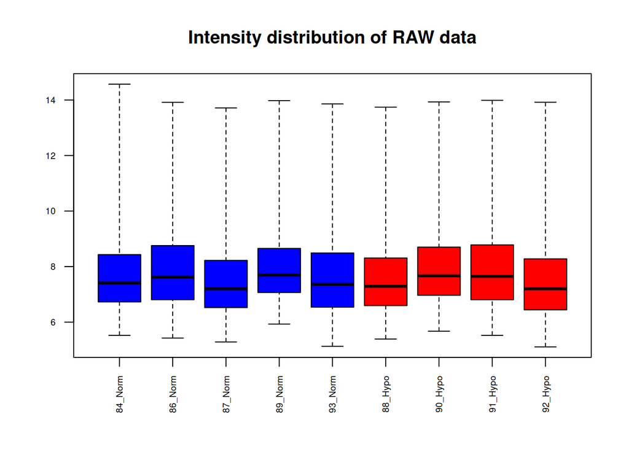

```r
# Boxplot RAW data
boxplot(rawData, which = "all", las = 2, main = "Intensity distribution of RAW data",
    cex.axis = 0.6, col = sampleColor, names = sampleNames)
```

```r
# Boxplot GDS Eset boxplot(gdsEset, which='all',las=2, main='Intensity
# distribution of GDS Eset', cex.axis=0.6, col=sampleColor, names=sampleNames)
```

#### 2.3.1.2 Agrupació Jeràrquica

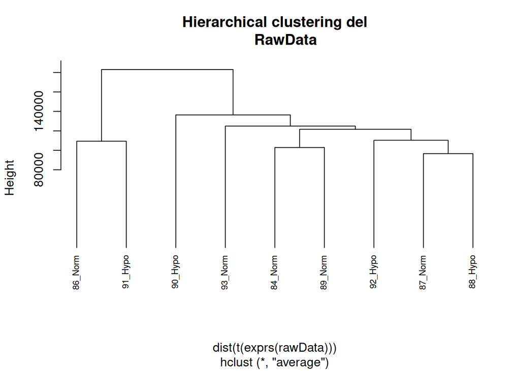

```r
# Hierarquical Clustering RAW data
clust.euclid.average <- hclust(dist(t(exprs(rawData))), method = "average")
plot(clust.euclid.average, labels = sampleNames, main = "Hierarchical clustering del
     RawData",
    cex = 0.7, hang = -1)
```

```r
# Hierarquical Clustering GDS Eset clust.euclid.average <-
# hclust(dist(t(exprs(gdsEset))),method='average') plot(clust.euclid.average,
# labels=sampleNames, main='Hierarchical clustering de GDS data', cex=0.7,
# hang=-1)
```

#### 2.3.1.3 Anàlisis de Components Principals (PCA)

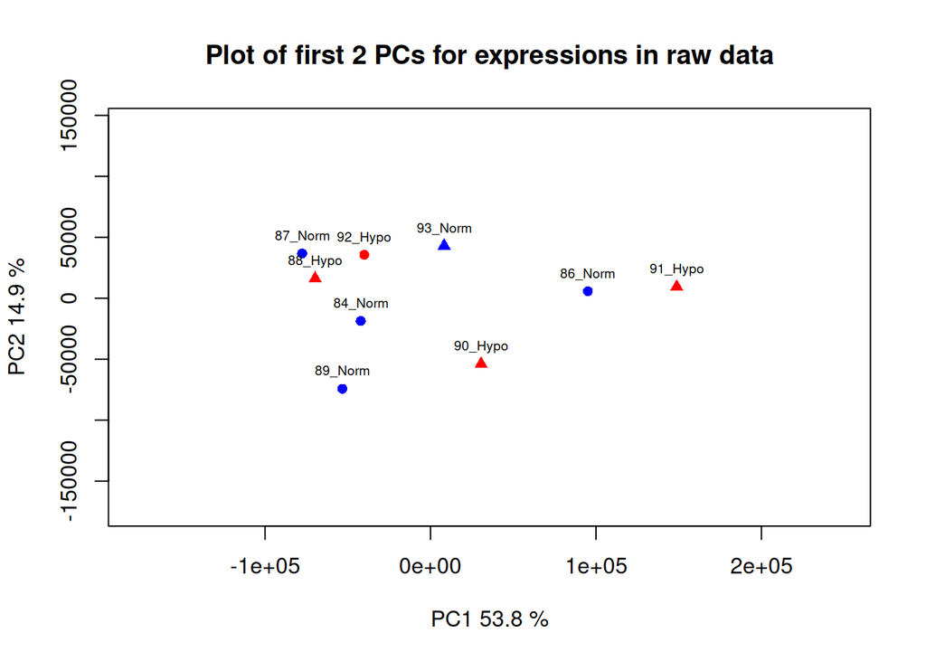

```r
# Anàlisis de Components Principals Definició de la funció
plotPCA <- function(X, labels = NULL, colors = NULL, dataDesc = "", scale = FALSE,
    formapunts = NULL, myCex = 0.8, ...) {
    pcX <- prcomp(t(X), scale = scale)  # o prcomp(t(X))
    loads <- round(pcX$sdev^2/sum(pcX$sdev^2) * 100, 1)
    xlab <- c(paste("PC1", loads[1], "%"))
    ylab <- c(paste("PC2", loads[2], "%"))
    if (is.null(colors))
        colors = 1
    plot(pcX$x[, 1:2], xlab = xlab, ylab = ylab, col = colors, pch = formapunts,
        xlim = c(min(pcX$x[, 1]) - 1e+05, max(pcX$x[, 1]) + 1e+05), ylim = c(min(pcX$x[,
            2]) - 1e+05, max(pcX$x[, 2]) + 1e+05))
    text(pcX$x[, 1], pcX$x[, 2], labels, pos = 3, cex = myCex)
    title(paste("Plot of first 2 PCs for expressions in", dataDesc, sep = " "), cex = 0.8)
}

# Raw data
plotPCA(exprs(rawData), labels = sampleNames, dataDesc = "raw data", colors = sampleColor,
    formapunts = c(rep(16, 4), rep(17, 4)), myCex = 0.6)
```

```r
# GDS Eset plotPCA(exprs(gdsEset), labels=sampleNames, dataDesc='GDS Eset',
# colors=sampleColor, formapunts=c(rep(16,4),rep(17,4)), myCex=0.6)
```

Guardem els anàlisi de qualitat en un arxiu PDF en el directori *results*

```r
# Ho gravem a un arxiu pdf al directori 'results'
pdf(file.path(resultsDir, "QCPlots_Raw.pdf"))
boxplot(rawData, which = "all", las = 2, main = "Intensity distribution of RAW data",
    cex.axis = 0.6, col = sampleColor, names = sampleNames)
plot(clust.euclid.average, labels = sampleNames, main = "Hierarchical clustering of samples of RawData",
    cex = 0.7, hang = -1)
plotPCA(exprs(rawData), labels = sampleNames, dataDesc = "raw data", colors = sampleColor,
    formapunts = c(rep(16, 4), rep(17, 4)), myCex = 0.6)
# Tanquem l'arxiu
dev.off()
```

### 2.3.2 Amb el paquet `arrayQualityMetrics`

Creem el directori *QC_RawData* on tindrem els resultats de l’anàlisis de qualitat fet per “arrayQualityMetrics” El control de qualitat amb *arrayQualityMetrics* consumeix cert temps pel que podem optar per executar-ho, o no fer-ho, usant una variable de tipus lògic.

```r
# Carreguem la llibreria 'arrayQualityMetrics'
require(arrayQualityMetrics)

# Evitem tornar-lo a executar cada vegada que s'executa l'script.
rerun <- FALSE
if (rerun) {
    # Raw Data
    arrayQualityMetrics(rawData, reporttitle = "QC_RawData", force = TRUE)
    # GDS Eset arrayQualityMetrics(gdsEset, reporttitle='QC_GDSEset',
    # force=TRUE)
}
```

## 2.4 Normalització

Fem servir el mètode RMA per normalitzar les dades Raw Data.

```r
# Normalitzem les dades Raw Data
myEset <- rma(rawData)
```

```
Background correcting
Normalizing
Calculating Expression
```

```r
write.exprs(myEset, file.path(resultsDir, "NormData.txt"))
myEset
```

```
ExpressionSet (storageMode: lockedEnvironment)
assayData: 15923 features, 9 samples
  element names: exprs
protocolData
  rowNames: 1 2 ... 9 (9 total)
  varLabels: exprs dates
  varMetadata: labelDescription channel
phenoData
  rowNames: 1 2 ... 9 (9 total)
  varLabels: fileName groups ShortName Colors
  varMetadata: labelDescription channel
featureData: none
experimentData: use 'experimentData(object)'
Annotation: pd.rae230a
```

Cal recordad que les dades descarregades amb GDS ja estan normalitzades.

## 2.5 Filtratge

```r
require(genefilter)
# Farem la base de dades rae230a.db que és la que correspon a la plataforma
# GPL0341 d'Affymetrix (microarray)
annotation(myEset) <- "rae230a.db"
eset_filtered <- nsFilter(myEset, var.func = IQR, var.cutoff = 0.75, var.filter = TRUE,
    require.entrez = TRUE, filterByQuantile = TRUE)
# Nombre de gens filtrats (esborrats)
print(eset_filtered)
```

```
$eset
ExpressionSet (storageMode: lockedEnvironment)
assayData: 2690 features, 9 samples
  element names: exprs
protocolData
  rowNames: 1 2 ... 9 (9 total)
  varLabels: exprs dates
  varMetadata: labelDescription channel
phenoData
  rowNames: 1 2 ... 9 (9 total)
  varLabels: fileName groups ShortName Colors
  varMetadata: labelDescription channel
featureData: none
experimentData: use 'experimentData(object)'
Annotation: rae230a.db

$filter.log
$filter.log$numDupsRemoved
[1] 2537

$filter.log$numLowVar
[1] 8070

$filter.log$numRemoved.ENTREZID
[1] 2620

$filter.log$feature.exclude
[1] 6
```

```r
# Nombre de Gens que resten
print(eset_filtered$eset)
```

```
ExpressionSet (storageMode: lockedEnvironment)
assayData: 2690 features, 9 samples
  element names: exprs
protocolData
  rowNames: 1 2 ... 9 (9 total)
  varLabels: exprs dates
  varMetadata: labelDescription channel
phenoData
  rowNames: 1 2 ... 9 (9 total)
  varLabels: fileName groups ShortName Colors
  varMetadata: labelDescription channel
featureData: none
experimentData: use 'experimentData(object)'
Annotation: rae230a.db
```

```r
filteredEset <- eset_filtered$eset
# filteredEset <- myEset
filteredData <- exprs(filteredEset)
# filteredData <- exprs(myEset)
head(filteredData)
```

```
                  1        2        3        4        5        6        7
1388383_at 8.322271 8.570291 8.322271 8.018906 8.647421 8.322271 8.167855
1373191_at 7.529336 7.675628 7.791007 7.867028 7.427315 7.759119 8.009510
1393669_at 5.474679 5.045734 5.066095 5.123502 4.911754 4.844921 5.441030
1372850_at 6.834757 7.131584 6.724878 6.492835 7.241871 7.010489 6.676976
1373964_at 6.844125 7.371164 7.320041 7.165110 7.316484 6.957853 6.921627
1390465_at 8.059365 7.558511 7.809494 7.809494 7.493047 7.867611 7.955898
                  8        9
1388383_at 8.610859 8.322271
1373191_at 7.910771 8.058584
1393669_at 4.299795 4.627790
1372850_at 7.172263 6.834757
1373964_at 7.282614 7.187036
1390465_at 7.522304 7.912767
```

```r
# colnames(filteredData) <- pData(eset_filtered$eset)$ShortName
colnames(filteredData) <- pData(filteredEset)$ShortName
```

## 2.6 Selección de genes

Construimos un modelo lineal, es decir una matriz de diseño y una de contrastes, para el análisis.

Primero la matriz de diseño

```r
library(limma)
treat <- pData(filteredEset)$groups
lev <- factor(treat, levels = unique(treat))
design <- model.matrix(~0 + lev)
colnames(design) <- levels(lev)
rownames(design) <- sampleNames
print(design)
```

```
        Control Hypotesion
84_Norm       1          0
86_Norm       1          0
87_Norm       1          0
89_Norm       1          0
93_Norm       1          0
88_Hypo       0          1
90_Hypo       0          1
91_Hypo       0          1
92_Hypo       0          1
attr(,"assign")
[1] 1 1
attr(,"contrasts")
attr(,"contrasts")$lev
[1] "contr.treatment"
```

A continuación la matriz de contraste

```r
# COMPARISON
cont.matrix1 <- makeContrasts(Hypotension.vs.Control = Hypotesion - Control, levels = design)
comparisonName <- "Efecte de la hipotensió induida"
print(cont.matrix1)
```

```
            Contrasts
Levels       Hypotension.vs.Control
  Control                        -1
  Hypotesion                      1
```

Estimamos el modelo

```r
# MODEL FIT
fit1 <- lmFit(filteredData, design)
fit.main1 <- contrasts.fit(fit1, cont.matrix1)
fit.main1 <- eBayes(fit.main1)
```

El resultado del análisis se encuentra en el objeto `lmfit` y puede extraerse con la instrucción “topTable”.

```r
topTab <- topTable(fit.main1, number = nrow(fit.main1), coef = "Hypotension.vs.Control",
    adjust = "fdr", lfc = 1, p.value = 0.05)
dim(topTab)
```

```
[1] 5 6
```

```r
head(topTab)
```

```
                 logFC  AveExpr         t      P.Value  adj.P.Val        B
1370080_at    1.197486 6.754096  5.310736 5.237648e-06 0.01408927 3.860589
1371754_at    1.128581 7.605038  4.783239 2.694802e-05 0.02510877 2.424056
1370384_a_at -1.116593 8.525278 -4.770784 2.800234e-05 0.02510877 2.390354
1374699_at    1.288099 6.025918  4.576299 5.086437e-05 0.02653925 1.866088
1368778_at   -1.213756 7.708883 -4.261152 1.322662e-04 0.03953289 1.026706
```

# 3 Resultats

## 3.1 Anotación de los resultados

Obtenemos los identificadores ENTREZ y GENE SYMBOL correspondientes a los probesets (identificados con los id de la compañía que produjo el microarray) que aparecen en la tabla de resultados.

```r
require(rae230a.db)
keytypes(rae230a.db)
```

```
 [1] "ACCNUM"       "ALIAS"        "ENSEMBL"      "ENSEMBLPROT"  "ENSEMBLTRANS"
 [6] "ENTREZID"     "ENZYME"       "EVIDENCE"     "EVIDENCEALL"  "GENENAME"
[11] "GENETYPE"     "GO"           "GOALL"        "IPI"          "ONTOLOGY"
[16] "ONTOLOGYALL"  "PATH"         "PFAM"         "PMID"         "PROBEID"
[21] "PROSITE"      "REFSEQ"       "SYMBOL"       "UNIPROT"
```

```r
anotaciones <- AnnotationDbi::select(rae230a.db, keys = rownames(filteredData), columns = c("ENTREZID",
    "SYMBOL", "GENENAME"))
```

Añadimos las columnas de anotaciones a la “topTable”.

Aunque esto se puede hacer de muchas formas utilizamos la metodología de concatenar las instrucciones usando “pipes” (%>%) y funciones del paquete `dplyr` que simplifican la lectura.

```r
library(dplyr)
topTabAnotada <- topTab %>%
    mutate(PROBEID = rownames(topTab)) %>%
    left_join(anotaciones) %>%
    arrange(P.Value) %>%
    select(7, 8, 9, 1:6, 10)

head(topTabAnotada)
```

```
       PROBEID ENTREZID   SYMBOL     logFC  AveExpr         t      P.Value
1   1370080_at    24451    Hmox1  1.197486 6.754096  5.310736 5.237648e-06
2   1371754_at   246771 Slc25a25  1.128581 7.605038  4.783239 2.694802e-05
3 1370384_a_at    24684     Prlr -1.116593 8.525278 -4.770784 2.800234e-05
4   1374699_at   313969   Lratd1  1.288099 6.025918  4.576299 5.086437e-05
5   1368778_at    29464   Slc6a6 -1.213756 7.708883 -4.261152 1.322662e-04
   adj.P.Val        B                           GENENAME
1 0.01408927 3.860589                   heme oxygenase 1
2 0.02510877 2.424056 solute carrier family 25 member 25
3 0.02510877 2.390354                 prolactin receptor
4 0.02653925 1.866088           LRAT domain containing 1
5 0.03953289 1.026706   solute carrier family 6 member 6
```

## 3.2 Visualización de resultados (1): Volcano Plot

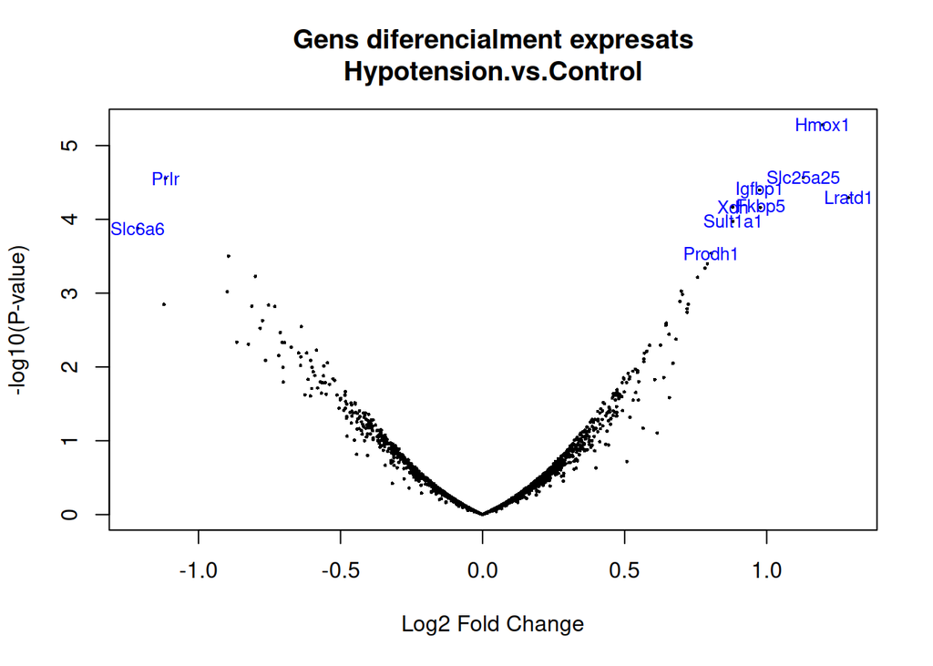

```r
# Anomenem amb SYMBOL els gens del model. Fem servir la base de dades
# d'anotacions rae230a.db
genenames <- AnnotationDbi::select(rae230a.db, rownames(fit.main1), c("SYMBOL"))$SYMBOL
volcanoplot(fit.main1, highlight = 10, names = genenames, main = paste("Gens diferencialment expresats",
    colnames(cont.matrix1), sep = "\n"))
abline(v = c(-3, 3))
```

```r
# El guardem a un pdf
pdf(file.path(resultsDir, "VolcanoPlot.pdf"))
volcanoplot(fit.main1, highlight = 10, names = genenames, main = paste("Gens diferencialment expresats",
    colnames(cont.matrix1), sep = "\n"))
abline(v = c(-3, 3))
dev.off()
```

## 3.3 Visualización de resultados (2): Heatmaps

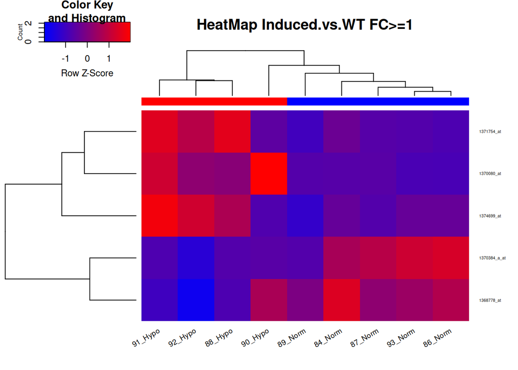

```r
selectedRows <- rownames(filteredData) %in% rownames(topTab)
selectedData <- filteredData[selectedRows, ]

# HEATMAP PLOT
my_palette <- colorRampPalette(c("blue", "red"))(n = 299)
library(gplots)
heatmap.2(selectedData, Rowv = TRUE, Colv = TRUE, main = "HeatMap Induced.vs.WT FC>=1",
    scale = "row", col = my_palette, sepcolor = "white", sepwidth = c(0.05, 0.05),
    cexRow = 0.5, cexCol = 0.9, key = TRUE, keysize = 1.5, density.info = "histogram",
    ColSideColors = c(rep("blue", 5), rep("red", 4)), tracecol = NULL, srtCol = 30)
```

```r
pdf(file.path(resultsDir, "Heatmap.pdf"))
heatmap.2(selectedData, Rowv = TRUE, Colv = TRUE, main = "HeatMap Induced.vs.WT FC>=1",
    scale = "row", col = my_palette, sepcolor = "white", sepwidth = c(0.05, 0.05),
    cexRow = 0.5, cexCol = 0.9, key = TRUE, keysize = 1.5, density.info = "histogram",
    ColSideColors = c(rep("blue", 5), rep("red", 4)), tracecol = NULL, srtCol = 30)
dev.off()
```

# 4 Análisis de significación biológica

A título ilustrativo realizaremos un análisis de enriquecimiento (“Over-Representation Analysis”) a partir de la lista de genes seleccionados como diferencialmente expresados.

Para el análisis necesitamos dos colecciones de genes

- La lista seleccionada
- El *universo de genes* es decir todos los genes que se han incluído en el análisis (hay quien pone todos los del chip o todos los del genoma).

La mayoría de programas necesitan que los identificadores de los genes sean en formato “ENTREZ” por lo que prepararemos ambas listas a la vez (aunque ya teníamos la de los genes seleccionados).

```r
require(rae230a.db)
probesUniverse <- rownames(filteredData)
entrezUniverse <- AnnotationDbi::select(rae230a.db, probesUniverse, "ENTREZID")$ENTREZID

topProbes <- rownames(selectedData)
entrezTop <- AnnotationDbi::select(rae230a.db, topProbes, "ENTREZID")$ENTREZID

# Eliminamos posibles duplicados

topGenes <- entrezTop[!duplicated(entrezTop)]
entrezUniverse <- entrezUniverse[!duplicated(entrezUniverse)]
```

Se pueden utilizar muchos paquetes para realizar un análisis de enriquecimiento genético. Cada uno de ellos realiza un análisis ligeramente diferente, pero las ideas subyacentes son las mismas.

En este ejemplo usamos “GOstats”, que fue uno de los primeros paquetes disponibles en Bioconductor para realizar análisis de enriquecimiento.

La idea para usarlo es bastante simple: necesitamos crear un tipo especial de objeto llamado “Hiperparámetro” que puede ser de clase:

```r
library(GOstats)

# This parameter has an 'ontology' argument. It may be 'BP', 'MF' or 'CC' Other
# arguments are taken by default. Check the help for more information.

GOparams = new("GOHyperGParams", geneIds = topGenes, universeGeneIds = entrezUniverse,
    annotation = "rae230a.db", ontology = "BP", pvalueCutoff = 0.01)
```

```r
GOhyper = hyperGTest(GOparams)
```

```r
head(summary(GOhyper))
```

```
      GOBPID      Pvalue OddsRatio    ExpCount Count Size
1 GO:0001762 0.001984915       Inf 0.001984915     1    1
2 GO:0006788 0.001984915       Inf 0.001984915     1    1
3 GO:0032762 0.001984915       Inf 0.001984915     1    1
4 GO:0032763 0.001984915       Inf 0.001984915     1    1
5 GO:0032764 0.001984915       Inf 0.001984915     1    1
6 GO:0038161 0.001984915       Inf 0.001984915     1    1
                                                  Term
1                               beta-alanine transport
2                                       heme oxidation
3                        mast cell cytokine production
4          regulation of mast cell cytokine production
5 negative regulation of mast cell cytokine production
6                          prolactin signaling pathway
```

```r
dim(summary(GOhyper))
```

```
[1] 33  7
```

```r
# Creamos un informe html con los resultados
GOfilename = file.path(resultsDir, "GOResults.html")
htmlReport(GOhyper, file = GOfilename, summary.args = list(htmlLinks = TRUE))
```

# 5 Discusió

# 6 Referències

(Timm H Westhoff 2005)

Timm H Westhoff, Markus Tölle, Stefanie Scheid. 2005. “A Physiogenomic Approach to Study the Regulation of Blood Pressure.” *Physiol Genomics*.